# Lab 11: Corridors and Least-Cost Paths

## Defining patches: where the species is now, and where it needs to go

A least-cost path connects two locations, so we need to decide what those are. We’ll do this in three steps.

**1. Decide what counts as “suitable.”** The SDM gives a continuous index, so we need a threshold. A common choice is the suitability value that includes 90% of your occurrence records (the 10th percentile of suitability at the occurrence points). Cells at or above that value are “suitable.”

```r
occ.proj <- project(occ.vect, proj.crs)
occ.suit <- extract(current.proj, occ.proj, ID = FALSE)[, 1]  # extract suitability values at every occ point

threshold <- as.numeric(quantile(occ.suit, probs = 0.10, na.rm = TRUE))
cat("threshold 1: ", threshold)
```

```
## threshold 1:  0.3023815
```

```r
threshold2 <- as.numeric(quantile(occ.suit, probs = 0.30, na.rm = TRUE))
cat("threshold 2: ", threshold2)
```

```
## threshold 2:  0.5805387
```

**2. Find the patches.** We identify the suitable cells in the current and future maps, then use `patches()` to group neighboring suitable cells into numbered patches.

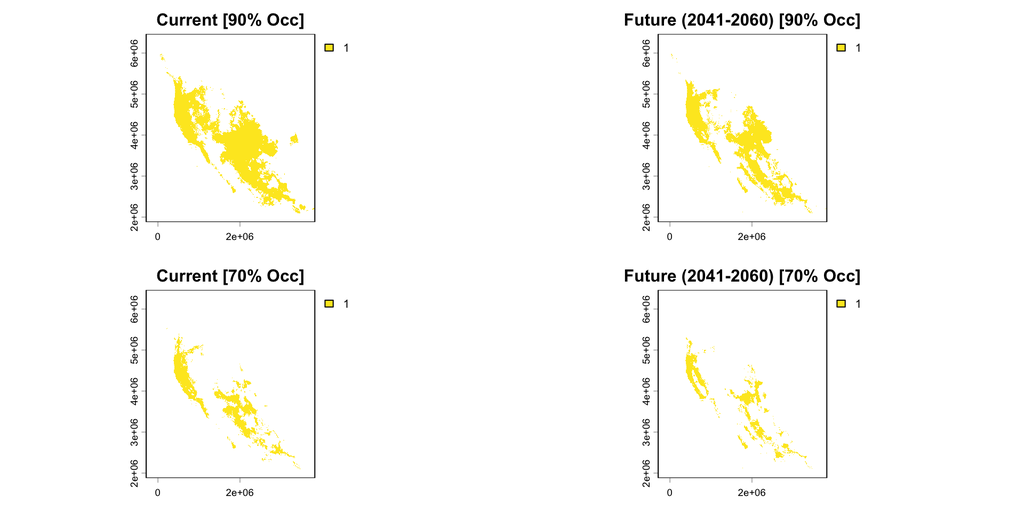

```r
current.suitable <- ifel(current.proj >= threshold, 1, NA)
future.suitable  <- ifel(future.proj  >= threshold, 1, NA)


current.suitable2 <- ifel(current.proj >= threshold2, 1, NA)
future.suitable2  <- ifel(future.proj  >= threshold2, 1, NA)

# New (2x2)
par(mfrow = c(2, 2))
plot(current.suitable, main = "Current [90% Occ]", range = c(0, 1))
plot(future.suitable, main = "Future (2041-2060) [90% Occ]", range = c(0, 1))
plot(current.suitable2, main = "Current [70% Occ]", range = c(0, 1))
plot(future.suitable2, main = "Future (2041-2060) [70% Occ]", range = c(0, 1))
```

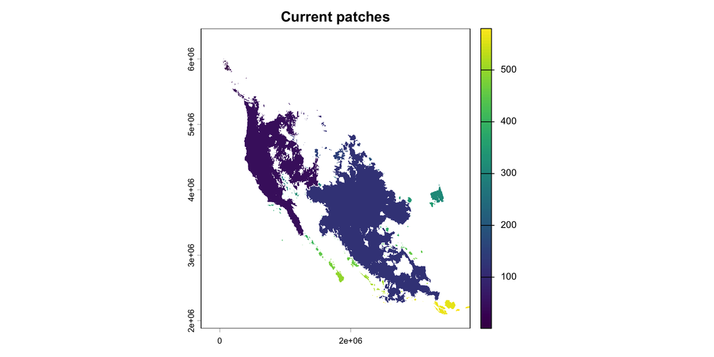

```r
par(mfrow = c(1, 1))

# Let's just use the first threshold
current.patches <- patches(current.suitable, directions = 8)
plot(current.patches, main = "Current patches")
```

```r
# calculate the size of each current patch, in km2
patch.sizes <- freq(current.patches)
patch.sizes$area.km2 <- patch.sizes$count * prod(res(current.proj)) / 1e6
head(patch.sizes)
```

```
##   layer value count area.km2
## 1     1     1     1       16
## 2     1     2    28      448
## 3     1     3     1       16
## 4     1     4     7      112
## 5     1     5   271     4336
## 6     1     6     4       64
```

We also find the **gain** areas: cells that are suitable in the future but not now. These are the places your species will need to reach.

```r
# which areas show future suitability but are not in the current 'suitable' map?
gain <- ifel(future.proj >= threshold & current.proj < threshold, 1, NA)
n.gain <- global(gain, "notNA")[1, 1]     # how many cells are gain area?
n.gain
```

```
## [1] 9708
```

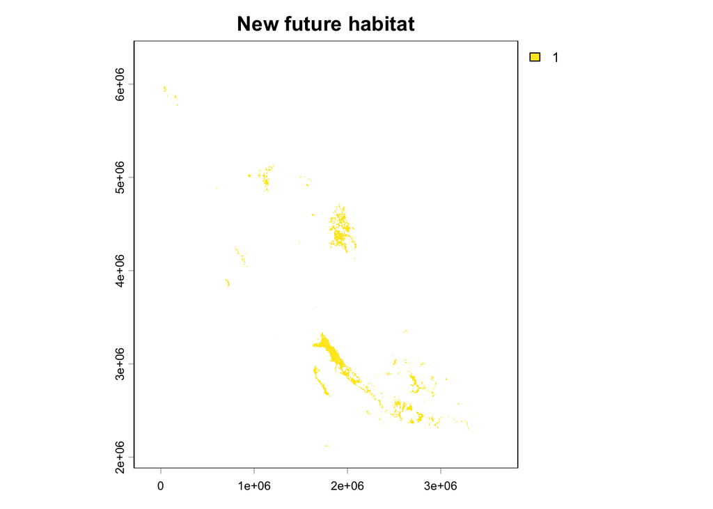

```r
plot(gain, main = "New future habitat")
```

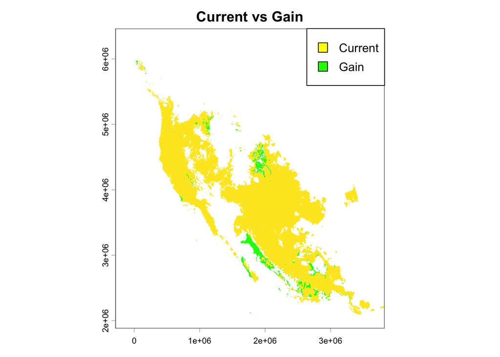

```r
# plot combined
plot(current.suitable, main = "Current vs Gain", range = c(0, 1),legend=F)
plot(gain,col="green",legend=F,add=T)
terra::add_legend("topright",legend=c("Current","Gain"),fill=c("yellow","green"))
```

If `n.gain` is 0, your species is projected to gain no new area, and you should skip the next chunk and use the “No gain area?” chunk below it instead.

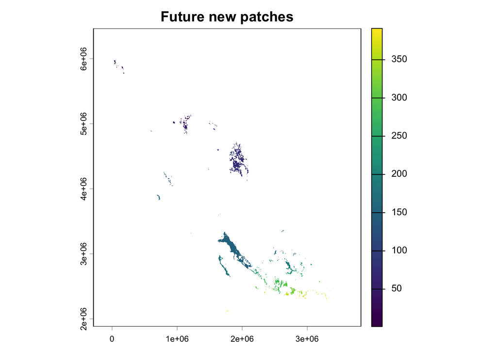

```r
gain.patches <- patches(gain, directions = 8)
plot(gain.patches, main = "Future new patches")
```

```r
gain.sizes <- freq(gain.patches)
gain.sizes$area.km2 <- gain.sizes$count * prod(res(current.proj)) / 1e6
head(gain.sizes)
```

```
##   layer value count area.km2
## 1     1     1    41      656
## 2     1     2     1       16
## 3     1     3    13      208
## 4     1     4     1       16
## 5     1     5     2       32
## 6     1     6     2       32
```

```r
# ONLY use this chunk if your species has no gain area. Instead of connecting a current patch to a
# new area, connect the two largest FUTURE patches (the future refuges):
future.patches <- patches(future.suitable, directions = 8)
future.sizes <- freq(future.patches)
future.sizes <- future.sizes[order(future.sizes$count, decreasing = TRUE), ]

# then, in the "source and destination" chunk below, use future.patches in place of
# current.patches (source = future.sizes$value[1]) and in place of gain.patches (destination = future.sizes$value[2])
```

**3. Pick one location to represent each patch.** We’ll connect the **largest current patch** (the source) to the **largest gain patch** (the destination), using the highest-suitability cell in each as the starting and ending points. Using one point per patch is a simplification, which we’ll come back to in Exercise 5. The function below finds that best cell; a function is just a reusable set of instructions, like the ones you’ve been calling from packages.

```r
# find the location of the highest-suitability cell within the given patch(es)
get.best.cells <- function(patch.raster, suit.raster, patch.ids) {
  xy <- NULL
  for (id in patch.ids) {
    cells <- ifel(patch.raster == id, suit.raster, NA)
    idx <- which.max(values(cells)[, 1])
    xy <- rbind(xy, xyFromCell(cells, idx))
  }
  xy
}  # after running this, the function you defined is now stored in your environment, and you can use it on your data

src.id  <- patch.sizes$value[which.max(patch.sizes$count)]   # Which current patch is largest?
dest.id <- gain.sizes$value[which.max(gain.sizes$count)]     # Which future gained patch is largest?

src.xy  <- get.best.cells(current.patches, current.proj, src.id)   # using the function you defined above
dest.xy <- get.best.cells(gain.patches, future.proj, dest.id)

src.xy
```

```
##            x       y
## [1,] 2023167 3158874
```

```r
dest.xy
```

```
##            x       y
## [1,] 1851167 3106874
```